# MATE35-TrabalhoPartePratica

**MATE35 - Tópicos em Sistemas Distribuídos I - Ciência de Dados**

**Prof:** Marcos Barreto

**Aluna:** Andréa Jesus dos Santos

## **TRABALHO PRÁTICO PARTE I**

1 - Importar bibliotecas (Item iii)

```python
import numpy as np
import pandas as pd
import seaborn as sns
import matplotlib.pyplot as plt
```

2 - Leitura do Dataset de óbitos por CID-10 (Item iv)

```python
dfMortalidadeCID10Original = pd.read_csv("C:/Users/Deinha/PycharmProjects/DataScience/Preparation/Resource"
                                         "/Obitos pResidenc por Unidade da Federacao segundo Grupo CID-10.csv",
                                         sep=",", encoding='ISO-8859-1')
```

**3 - Preparação dos Dados (Item ii)**

**3.1 - Conjunto de dados (data set) escolhido: Óbitos por Residência por Unidade da Federacao segundo Grupo CID-10**

Origem dos dados Os dados disponíveis são oriundos do Sistema de Informações sobre Mortalidade (SIM), sistema este gerido pelo Departamento de Análise de Situação de Saúde, da Secretaria de Vigilância em Saúde, em conjunto com as Secretarias Estaduais e Municipais de Saúde. As Secretarias de Saúde coletam as Declarações de Óbitos dos cartórios e entram, no SIM, as informações nelas contidas. Uma das informações primordiais é a causa básica de óbito, a qual é codificada a partir do declarado pelo médico atestante, segundo regras estabelecidas pela Organização Mundial de Saúde. A partir de 1996, as declarações de óbito passaram a ser codificadas utilizando-se a 10ª Revisão da Classificação Internacional de Doenças - CID-10. Até então, era utilizada a 9ª Revisão - CID-9. Devido às diferenças entre as revisões, não foi possível gerar uma lista que as compatibilizasse. Em 2011, houve uma mudança no conteúdo da Declaração de Óbito, com maior detalhamento das informações coletadas. Para este ano, foram utilizados simultaneamente os dois formulários. Para mais detalhes sobre as mudanças ocorridas e os seus efeitos, veja o documento "Sistema de Informações sobre Mortalidade - SIM. Consolidação da base de dados de 2011".

Óbitos por residência Número de óbitos ocorridos, contados segundo o local de residência do falecido.

Capítulo CID 10, Grupo CID-10, Categoria CID-10, Causa - CID-BR-10 Causa do óbito, segundo a Classificação Internacional de Doenças. Até 1995, inclusive, era utilizada a CID-9 - 9ª Revisão da Classificação. A partir de 1996, passou-se a utilizar a CID-10 - 10ª Revisão da Classificação. Por não existir uma relação biunívoca entre a CID-9 e a CID-10, não existe uma tabela de conversão direta entre as classificações. A causa de óbito pode ser recuperada segundo:  22 Capítulos  264 Grupos  2045 Categorias  144 elementos da Lista CID-BR 28  4 elementos da lista de causas mal definidas

3.2 - Informações sobre o data set

-> número de observações - 238 -> número de variáveis - 27 -> Significado - Mortalidade no Brasil por unidade da federação. -> valores válidos para cada variável

```python
# Reindexar a 1ª coluna e apagar coluna "Grupo CID-10"
dfMortalidadeCID10 = dfMortalidadeCID10Original
dfMortalidadeCID10 = dfMortalidadeCID10.set_index(dfMortalidadeCID10Original["Grupo CID-10"])
dfMortalidadeCID10 = dfMortalidadeCID10.drop(labels=["Grupo CID-10"], axis=1, inplace=False)


def converterParaFloat(valor):
    # Trocar os valores "-" por Nan e converte os valores para float para posteriomente utilizar os métodos do pandas
    valor_str = str(valor)
    result = valor

    if valor_str == "-":
        result = np.nan

    return float(result)


# Altarar os campos vazios/não preenchidos para Nan (neste dataset é vazio/não preenchidos representado por "-")
dfMortalidadeCID10 = dfMortalidadeCID10.applymap(lambda x: converterParaFloat(x))

# Excluir a observação(linha), o atributo(coluna) com a totalização
dfMortalidadeCID10 = dfMortalidadeCID10.drop(labels=["Total"], axis=0, inplace=False)
dfMortalidadeCID10 = dfMortalidadeCID10.drop(labels=["Total"], axis=1, inplace=False)

# Excluir observações (linhas) e atributos (colunas) 100% nulas, se houver
dfMortalidadeCID10.dropna(axis=0, how="all")
dfMortalidadeCID10.dropna(axis=1, how="all")
```

| Grupo CID-10 | RO | AC | AM | RR | PA | AP | TO | MA | PI | CE | ... | ES | RJ | SP | PR | SC | RS | MS | MT | GO | DF |
| --- | --- | --- | --- | --- | --- | --- | --- | --- | --- | --- | --- | --- | --- | --- | --- | --- | --- | --- | --- | --- | --- |
| Doenças infecciosas intestinais | 899.0 | 722.0 | 3137.0 | 450.0 | 5272.0 | 305.0 | 1005.0 | 4733.0 | 3179.0 | 10246.0 | ... | 1640.0 | 5489.0 | 15699.0 | 5332.0 | 2205.0 | 4365.0 | 2343.0 | 1672.0 | 2228.0 | 776.0 |
| Tuberculose | 654.0 | 430.0 | 2342.0 | 148.0 | 3545.0 | 219.0 | 282.0 | 3109.0 | 1353.0 | 4803.0 | ... | 1499.0 | 19445.0 | 23019.0 | 3619.0 | 1240.0 | 5982.0 | 1305.0 | 1727.0 | 1303.0 | 366.0 |
| Algumas doenças bacterianas zoonóticas | 41.0 | 47.0 | 102.0 | 2.0 | 489.0 | 39.0 | 7.0 | 168.0 | 13.0 | 253.0 | ... | 113.0 | 1080.0 | 1583.0 | 680.0 | 326.0 | 602.0 | 9.0 | 19.0 | 37.0 | 48.0 |
| Outras doenças bacterianas | 2242.0 | 1110.0 | 4165.0 | 457.0 | 12756.0 | 1062.0 | 1277.0 | 7538.0 | 3272.0 | 16172.0 | ... | 3522.0 | 55027.0 | 58191.0 | 12440.0 | 8958.0 | 15447.0 | 2759.0 | 4277.0 | 6247.0 | 1269.0 |
| Infecções de transmissão predominantemente sexual | 17.0 | 23.0 | 82.0 | 9.0 | 133.0 | 23.0 | 28.0 | 134.0 | 58.0 | 86.0 | ... | 72.0 | 785.0 | 333.0 | 125.0 | 54.0 | 203.0 | 34.0 | 48.0 | 52.0 | 17.0 |
| Outras doenças por espiroquetas | 1.0 | NaN | 2.0 | 2.0 | 7.0 | 1.0 | 2.0 | 12.0 | 1.0 | 2.0 | ... | NaN | 7.0 | 35.0 | 3.0 | 14.0 | 9.0 | 1.0 | 6.0 | 5.0 | 1.0 |
| Outras doenças causadas por clamídias | NaN | NaN | NaN | NaN | NaN | NaN | NaN | 2.0 | NaN | NaN | ... | NaN | 1.0 | NaN | NaN | NaN | 1.0 | NaN | NaN | NaN | 1.0 |
| Rickettsioses | NaN | NaN | NaN | 1.0 | NaN | NaN | NaN | NaN | NaN | NaN | ... | 11.0 | 23.0 | 193.0 | 4.0 | NaN | NaN | NaN | 1.0 | NaN | NaN |
| Infecções virais do sistema nervoso central | 49.0 | 35.0 | 76.0 | 15.0 | 289.0 | 13.0 | 46.0 | 187.0 | 36.0 | 229.0 | ... | 78.0 | 380.0 | 1227.0 | 355.0 | 227.0 | 338.0 | 90.0 | 118.0 | 157.0 | 59.0 |
| Febres por arbovírus e febres hemorrágicas virais | 88.0 | 26.0 | 146.0 | 31.0 | 263.0 | 46.0 | 50.0 | 253.0 | 71.0 | 617.0 | ... | 216.0 | 1010.0 | 1070.0 | 241.0 | 59.0 | 33.0 | 182.0 | 314.0 | 728.0 | 113.0 |
| Infecções virais caract p/lesões de pele e mucosas | 33.0 | 23.0 | 160.0 | 21.0 | 158.0 | 18.0 | 43.0 | 137.0 | 73.0 | 191.0 | ... | 90.0 | 425.0 | 1418.0 | 244.0 | 146.0 | 258.0 | 78.0 | 92.0 | 154.0 | 76.0 |
| Hepatite viral | 502.0 | 810.0 | 1285.0 | 89.0 | 1183.0 | 65.0 | 180.0 | 850.0 | 294.0 | 634.0 | ... | 757.0 | 5599.0 | 14937.0 | 2591.0 | 1403.0 | 6109.0 | 490.0 | 575.0 | 1001.0 | 417.0 |
| Doença pelo vírus da imunodeficiência humana [HIV] | 1261.0 | 236.0 | 3624.0 | 493.0 | 7364.0 | 400.0 | 653.0 | 4703.0 | 1614.0 | 5035.0 | ... | 4054.0 | 36529.0 | 75913.0 | 11194.0 | 10730.0 | 27096.0 | 2935.0 | 3429.0 | 4982.0 | 2591.0 |
| Outras doenças por vírus | 15.0 | 4.0 | 49.0 | 8.0 | 91.0 | 2.0 | 14.0 | 76.0 | 67.0 | 165.0 | ... | 30.0 | 192.0 | 359.0 | 127.0 | 58.0 | 116.0 | 45.0 | 60.0 | 52.0 | 34.0 |
| Micoses | 183.0 | 30.0 | 85.0 | 14.0 | 290.0 | 15.0 | 82.0 | 111.0 | 69.0 | 170.0 | ... | 155.0 | 663.0 | 2309.0 | 684.0 | 241.0 | 620.0 | 158.0 | 346.0 | 242.0 | 64.0 |
| Doenças devidas a protozoários | 585.0 | 193.0 | 414.0 | 126.0 | 1350.0 | 140.0 | 1302.0 | 1153.0 | 1667.0 | 1760.0 | ... | 172.0 | 1427.0 | 26649.0 | 5139.0 | 195.0 | 870.0 | 1225.0 | 1510.0 | 16400.0 | 4426.0 |
| Helmintíases | 73.0 | 29.0 | 61.0 | 8.0 | 113.0 | 12.0 | 36.0 | 231.0 | 55.0 | 290.0 | ... | 332.0 | 497.0 | 2423.0 | 618.0 | 123.0 | 234.0 | 63.0 | 102.0 | 201.0 | 111.0 |
| Pediculose, acaríase e outras infestações | 5.0 | 5.0 | 10.0 | 2.0 | 33.0 | 2.0 | 12.0 | 23.0 | 21.0 | 31.0 | ... | 17.0 | 99.0 | 133.0 | 31.0 | 17.0 | 50.0 | 15.0 | 19.0 | 19.0 | 4.0 |
| Seqüelas de doenças infecciosas e parasitárias | 66.0 | 22.0 | 271.0 | 28.0 | 205.0 | 18.0 | 64.0 | 238.0 | 114.0 | 901.0 | ... | 245.0 | 847.0 | 2354.0 | 693.0 | 218.0 | 768.0 | 152.0 | 152.0 | 241.0 | 97.0 |
| Agentes infec bacter, virais e outr agentes infecc | NaN | NaN | 3.0 | NaN | NaN | NaN | NaN | NaN | NaN | NaN | ... | NaN | NaN | NaN | NaN | NaN | NaN | NaN | NaN | NaN | NaN |
| Outras doenças infecciosas | 11.0 | 1.0 | 10.0 | 1.0 | 34.0 | 2.0 | 4.0 | 34.0 | 34.0 | 161.0 | ... | 75.0 | 486.0 | 271.0 | 56.0 | 34.0 | 46.0 | 20.0 | 22.0 | 37.0 | 2.0 |
| Neoplasias malignas | 15975.0 | 6277.0 | 33201.0 | 3742.0 | 57591.0 | 4984.0 | 12656.0 | 45519.0 | 32916.0 | 117618.0 | ... | 60306.0 | 366983.0 | 866429.0 | 217016.0 | 123110.0 | 313494.0 | 39670.0 | 35181.0 | 81688.0 | 36334.0 |
| . Neoplasias malignas de localizações especificada | 13189.0 | 4572.0 | 28681.0 | 2942.0 | 48791.0 | 4310.0 | 10494.0 | 38784.0 | 28067.0 | 97878.0 | ... | 53145.0 | 316411.0 | 735290.0 | 189219.0 | 105469.0 | 272384.0 | 34589.0 | 29435.0 | 69526.0 | 31167.0 |
| ... Neoplasias malig do lábio, cavidade oral e far | 527.0 | 124.0 | 838.0 | 108.0 | 1825.0 | 147.0 | 320.0 | 1169.0 | 1099.0 | 4352.0 | ... | 3023.0 | 14754.0 | 34419.0 | 9339.0 | 4497.0 | 9218.0 | 1625.0 | 1377.0 | 3288.0 | 1139.0 |
| ... Neoplasias malignas dos órgãos digestivos | 4930.0 | 1721.0 | 10111.0 | 1006.0 | 18255.0 | 1613.0 | 3520.0 | 12913.0 | 9279.0 | 35994.0 | ... | 21178.0 | 114148.0 | 290993.0 | 74991.0 | 39607.0 | 101632.0 | 12779.0 | 10360.0 | 24204.0 | 11452.0 |
| ... Neopl malig aparelho respirat e órgãos intrato | 2473.0 | 900.0 | 5245.0 | 507.0 | 7752.0 | 751.0 | 1602.0 | 5708.0 | 4295.0 | 16484.0 | ... | 8800.0 | 59194.0 | 132190.0 | 33388.0 | 22160.0 | 64136.0 | 6319.0 | 5341.0 | 12962.0 | 5103.0 |
| ... Neopl malig dos ossos e cartilagens articulare | 156.0 | 53.0 | 398.0 | 45.0 | 791.0 | 98.0 | 170.0 | 673.0 | 503.0 | 1318.0 | ... | 497.0 | 2652.0 | 7031.0 | 2095.0 | 980.0 | 2226.0 | 451.0 | 448.0 | 892.0 | 380.0 |
| ... Melanoma e outras(os) neoplasias malignas da p | 273.0 | 73.0 | 375.0 | 47.0 | 713.0 | 45.0 | 185.0 | 575.0 | 728.0 | 2155.0 | ... | 977.0 | 4785.0 | 13979.0 | 4559.0 | 3415.0 | 6239.0 | 592.0 | 578.0 | 1334.0 | 600.0 |
| ... Neopl malig do tecido mesotelial e tecidos mol | 221.0 | 48.0 | 475.0 | 46.0 | 783.0 | 80.0 | 149.0 | 620.0 | 521.0 | 1395.0 | ... | 643.0 | 3987.0 | 10135.0 | 2222.0 | 1572.0 | 3313.0 | 417.0 | 385.0 | 1035.0 | 528.0 |
| ... Neoplasias malignas da mama | 815.0 | 272.0 | 1740.0 | 180.0 | 3452.0 | 207.0 | 662.0 | 2479.0 | 2145.0 | 8245.0 | ... | 3953.0 | 34599.0 | 66917.0 | 13897.0 | 7787.0 | 21223.0 | 2604.0 | 2114.0 | 5423.0 | 3045.0 |
| ... | ... | ... | ... | ... | ... | ... | ... | ... | ... | ... | ... | ... | ... | ... | ... | ... | ... | ... | ... | ... | ... |
| ... Ocupante veíc transp pesado traumat acid trans | 146.0 | 20.0 | 61.0 | 52.0 | 349.0 | 13.0 | 186.0 | 376.0 | 165.0 | 420.0 | ... | 339.0 | 684.0 | 1895.0 | 1541.0 | 1286.0 | 1121.0 | 427.0 | 553.0 | 659.0 | 102.0 |
| ... Ocupante ônibus traumat acidente de transporte | 49.0 | 4.0 | 52.0 | 9.0 | 104.0 | 4.0 | 27.0 | 129.0 | 40.0 | 154.0 | ... | 42.0 | 273.0 | 588.0 | 306.0 | 153.0 | 223.0 | 56.0 | 65.0 | 179.0 | 50.0 |
| ... Outros acidentes de transporte terrestre | 4430.0 | 1050.0 | 1872.0 | 438.0 | 5284.0 | 1148.0 | 1292.0 | 5872.0 | 3308.0 | 6743.0 | ... | 4828.0 | 14800.0 | 58026.0 | 15918.0 | 8214.0 | 16111.0 | 3577.0 | 3970.0 | 11687.0 | 1224.0 |
| ... Acidentes de transporte por água | 29.0 | 43.0 | 583.0 | 18.0 | 331.0 | 39.0 | 33.0 | 95.0 | 9.0 | 48.0 | ... | 17.0 | 137.0 | 128.0 | 115.0 | 65.0 | 43.0 | 21.0 | 66.0 | 41.0 | 10.0 |
| ... Acidentes de transporte aéreo e espacial | 22.0 | 28.0 | 134.0 | 9.0 | 120.0 | 6.0 | 17.0 | 37.0 | 14.0 | 40.0 | ... | 39.0 | 198.0 | 609.0 | 160.0 | 77.0 | 184.0 | 76.0 | 104.0 | 112.0 | 74.0 |
| ... Outros acidentes de transporte e os não especi | 337.0 | 9.0 | 17.0 | 67.0 | 1208.0 | 32.0 | 240.0 | 284.0 | 58.0 | 975.0 | ... | 25.0 | 114.0 | 2151.0 | 81.0 | 70.0 | 314.0 | 16.0 | 233.0 | 368.0 | 34.0 |
| . Outras causas externas de traumatismos acidentai | 5363.0 | 1665.0 | 9229.0 | 1276.0 | 15604.0 | 1640.0 | 3805.0 | 11671.0 | 5962.0 | 20795.0 | ... | 13537.0 | 58650.0 | 120339.0 | 31547.0 | 17257.0 | 28990.0 | 7362.0 | 10140.0 | 15630.0 | 6794.0 |
| ... Quedas | 1268.0 | 386.0 | 1954.0 | 181.0 | 3602.0 | 215.0 | 945.0 | 2541.0 | 1584.0 | 6400.0 | ... | 6364.0 | 21439.0 | 45725.0 | 13955.0 | 5095.0 | 10024.0 | 2247.0 | 2586.0 | 6081.0 | 3129.0 |
| ... Exposição a forças mecânicas inanimadas | 611.0 | 123.0 | 661.0 | 196.0 | 2270.0 | 64.0 | 281.0 | 1182.0 | 481.0 | 736.0 | ... | 418.0 | 1138.0 | 3506.0 | 1738.0 | 1043.0 | 1449.0 | 356.0 | 1665.0 | 777.0 | 182.0 |
| ... Exposição a forças mecânicas animadas | 52.0 | 21.0 | 35.0 | 10.0 | 120.0 | 10.0 | 66.0 | 117.0 | 50.0 | 92.0 | ... | 41.0 | 99.0 | 334.0 | 179.0 | 90.0 | 184.0 | 85.0 | 129.0 | 152.0 | 27.0 |
| ... Afogamento e submersão acidentais | 1610.0 | 730.0 | 3767.0 | 544.0 | 5090.0 | 1005.0 | 1063.0 | 3162.0 | 2000.0 | 6618.0 | ... | 3330.0 | 7256.0 | 23118.0 | 7143.0 | 4714.0 | 6944.0 | 1969.0 | 2936.0 | 3510.0 | 1084.0 |
| ... Outros riscos acidentais à respiração | 283.0 | 63.0 | 299.0 | 76.0 | 465.0 | 67.0 | 136.0 | 396.0 | 163.0 | 1321.0 | ... | 982.0 | 12401.0 | 10022.0 | 3694.0 | 1174.0 | 2932.0 | 857.0 | 625.0 | 751.0 | 897.0 |
| ... Expos corr elétr, radiação e temp press extrem | 339.0 | 158.0 | 666.0 | 90.0 | 1172.0 | 128.0 | 349.0 | 1729.0 | 677.0 | 2116.0 | ... | 467.0 | 2111.0 | 3535.0 | 941.0 | 1321.0 | 2208.0 | 392.0 | 741.0 | 1582.0 | 421.0 |
| ... Exposição à fumaça, ao fogo e às chamas | 131.0 | 63.0 | 295.0 | 47.0 | 466.0 | 40.0 | 146.0 | 329.0 | 169.0 | 508.0 | ... | 316.0 | 2488.0 | 4188.0 | 1662.0 | 774.0 | 2128.0 | 398.0 | 338.0 | 574.0 | 191.0 |
| ... Contato com fonte de calor ou substâncias quen | 7.0 | 4.0 | 5.0 | 2.0 | 41.0 | 3.0 | 6.0 | 39.0 | 20.0 | 68.0 | ... | 23.0 | 50.0 | 135.0 | 98.0 | 29.0 | 59.0 | 8.0 | 28.0 | 50.0 | 5.0 |
| ... Contato com animais e plantas venenosos | 43.0 | 50.0 | 222.0 | 60.0 | 431.0 | 38.0 | 117.0 | 277.0 | 133.0 | 150.0 | ... | 80.0 | 103.0 | 315.0 | 214.0 | 99.0 | 126.0 | 97.0 | 182.0 | 205.0 | 23.0 |
| ... Exposição às forças da natureza | 71.0 | 11.0 | 138.0 | 17.0 | 197.0 | 12.0 | 102.0 | 117.0 | 92.0 | 88.0 | ... | 39.0 | 1609.0 | 622.0 | 267.0 | 234.0 | 258.0 | 193.0 | 163.0 | 193.0 | 26.0 |
| ... Envenenamento acidental e exposição subst noci | 80.0 | 26.0 | 810.0 | 31.0 | 252.0 | 23.0 | 65.0 | 339.0 | 169.0 | 284.0 | ... | 263.0 | 1045.0 | 2139.0 | 473.0 | 264.0 | 389.0 | 276.0 | 156.0 | 290.0 | 314.0 |
| ... Excesso de esforços, viagens e privações | 3.0 | NaN | 1.0 | NaN | 7.0 | 2.0 | 1.0 | 18.0 | 3.0 | 9.0 | ... | 4.0 | 4.0 | 16.0 | 7.0 | 4.0 | 4.0 | 11.0 | 4.0 | 7.0 | NaN |
| ... Exposição acidental a outr fatores e aos não e | 865.0 | 30.0 | 376.0 | 22.0 | 1491.0 | 33.0 | 528.0 | 1425.0 | 421.0 | 2405.0 | ... | 1210.0 | 8907.0 | 26684.0 | 1176.0 | 2416.0 | 2285.0 | 473.0 | 587.0 | 1458.0 | 495.0 |
| Lesões autoprovocadas intencionalmente | 1460.0 | 632.0 | 2796.0 | 619.0 | 3788.0 | 624.0 | 1404.0 | 3205.0 | 3516.0 | 9495.0 | ... | 3048.0 | 8832.0 | 38448.0 | 13279.0 | 10090.0 | 22716.0 | 3828.0 | 3249.0 | 7118.0 | 2308.0 |
| Agressões | 10829.0 | 3289.0 | 17445.0 | 2713.0 | 45352.0 | 4370.0 | 5476.0 | 24315.0 | 7904.0 | 46877.0 | ... | 33825.0 | 134893.0 | 200618.0 | 56016.0 | 13863.0 | 43880.0 | 14032.0 | 20277.0 | 36674.0 | 15511.0 |
| Eventos (fatos) cuja intenção é indeterminada | 1156.0 | 402.0 | 876.0 | 453.0 | 2763.0 | 176.0 | 623.0 | 3302.0 | 1489.0 | 6398.0 | ... | 2226.0 | 41207.0 | 61460.0 | 6626.0 | 2356.0 | 9882.0 | 1732.0 | 1909.0 | 5641.0 | 436.0 |
| Intervenções legais e operações de guerra | 12.0 | 3.0 | NaN | 7.0 | 27.0 | 2.0 | 36.0 | 33.0 | 10.0 | 29.0 | ... | 15.0 | 4366.0 | 2799.0 | 469.0 | 217.0 | 215.0 | 72.0 | 58.0 | 32.0 | 14.0 |
| Complicações de assistência médica e cirúrgica | 201.0 | 64.0 | 91.0 | 11.0 | 423.0 | 30.0 | 87.0 | 885.0 | 141.0 | 1312.0 | ... | 132.0 | 3589.0 | 6310.0 | 755.0 | 256.0 | 847.0 | 394.0 | 218.0 | 484.0 | 103.0 |
| . Ef advers drog, medic e subst biológ finalid ter | 12.0 | 4.0 | 5.0 | 1.0 | 48.0 | 5.0 | 23.0 | 38.0 | 18.0 | 37.0 | ... | 22.0 | 372.0 | 550.0 | 130.0 | 32.0 | 172.0 | 37.0 | 31.0 | 55.0 | 17.0 |
| . Acid ocorr pacientes prest cuid médicos e cirúrg | 6.0 | 4.0 | 1.0 | 1.0 | 7.0 | NaN | 2.0 | 11.0 | 3.0 | 11.0 | ... | 8.0 | 24.0 | 64.0 | 34.0 | 7.0 | 18.0 | 4.0 | 3.0 | 22.0 | 36.0 |
| . Incid advers atos diagn terap assoc disposit méd | 2.0 | NaN | NaN | NaN | 4.0 | NaN | 2.0 | 8.0 | 5.0 | 8.0 | ... | 2.0 | 18.0 | 44.0 | 36.0 | 3.0 | 48.0 | 43.0 | 1.0 | 8.0 | 3.0 |
| . Reaç anorm compl tard proc cirúrg méd s/menç aci | 181.0 | 56.0 | 85.0 | 9.0 | 364.0 | 25.0 | 60.0 | 828.0 | 115.0 | 1256.0 | ... | 100.0 | 3175.0 | 5652.0 | 555.0 | 214.0 | 609.0 | 310.0 | 183.0 | 399.0 | 47.0 |
| Seqüelas causas externas de morbidade e mortalidad | 30.0 | 13.0 | 20.0 | 4.0 | 143.0 | 2.0 | 41.0 | 146.0 | 100.0 | 193.0 | ... | 318.0 | 291.0 | 1308.0 | 1047.0 | 227.0 | 700.0 | 156.0 | 89.0 | 249.0 | 147.0 |

238 rows × 27 columns

4 - Análise dos Dados (Item v)

```python
# Análise da Distribuição
print("-=--=-=--=-= Qtde de linhas e colunas do Dataset Mortalidade por Unidade da Federeal por Grupo CID-10 -=-=--==")
print(dfMortalidadeCID10.shape, "\n")

print("-=--=-=--=-=Tipos de Dados do Dataset Mortalidade por Unidade da Federeal por Grupo CID-10 -=-=--=-=--=-=-=-==")
dfMortalidadeCID10.info()
print("\n")

print("-=--=-=--=-=-=-=-=- Amostra dos Campos da Mortalidade por Unidade da Federeal por Grupo CID-10 -=-=--=-==-=-=-")
print(dfMortalidadeCID10.head(5))
print(dfMortalidadeCID10.tail(5), "\n")

print("-=--=-=-=-=-=-=-=-=- Distribuição da Mortalidade por Unidade da Federeal por Groupo CID-10 -=-=--=-==-=-=--=-=")
# Exploração dos dados para os valores numéricos
dfResumoMortalidadeCID10 = dfMortalidadeCID10.describe()
print(dfResumoMortalidadeCID10, "\n")
```

```
-=--=-=--=-= Qtde de linhas e colunas do Dataset Mortalidade por Unidade da Federeal por Grupo CID-10 -=-=--==
(238, 27)

-=--=-=--=-=Tipos de Dados do Dataset Mortalidade por Unidade da Federeal por Grupo CID-10 -=-=--=-=--=-=-=-==
<class 'pandas.core.frame.DataFrame'>
Index: 238 entries, Doenças infecciosas intestinais to Seqüelas causas externas de morbidade e mortalidad
Data columns (total 27 columns):
RO    216 non-null float64
AC    202 non-null float64
AM    214 non-null float64
RR    201 non-null float64
PA    228 non-null float64
AP    206 non-null float64
TO    217 non-null float64
MA    227 non-null float64
PI    224 non-null float64
CE    229 non-null float64
RN    221 non-null float64
PB    229 non-null float64
PE    228 non-null float64
AL    224 non-null float64
SE    219 non-null float64
BA    234 non-null float64
MG    235 non-null float64
ES    222 non-null float64
RJ    233 non-null float64
SP    233 non-null float64
PR    224 non-null float64
SC    224 non-null float64
RS    228 non-null float64
MS    213 non-null float64
MT    224 non-null float64
GO    224 non-null float64
DF    214 non-null float64
dtypes: float64(27)
memory usage: 52.1+ KB


-=--=-=--=-=-=-=-=- Amostra dos Campos da Mortalidade por Unidade da Federeal por Grupo CID-10 -=-=--=-==-=-=-
                                                       RO      AC      AM  \
```

[output cut: 143 more lines]

```
50%       699.000000     315.500000     694.000000    199.000000
75%      3910.250000    2151.000000    4373.000000   1225.000000
max    217016.000000  123110.000000  313494.000000  39670.000000

                 MT            GO            DF
count    224.000000    224.000000    214.000000
mean    1799.370536   3874.379464   1464.009346
std     4869.027523  10710.114249   4273.776439
min        1.000000      1.000000      1.000000
25%       44.500000     60.250000     26.250000
50%      180.500000    311.000000    145.000000
75%     1030.500000   2233.500000    673.250000
max    35181.000000  81688.000000  36334.000000

[8 rows x 27 columns]
```

5 - Imputação (Item vi e vii) Executei a imputação de 3 formas (inclusão de zeros, média e mediana) para avaliar qual destas técnicas se materia o mais próximo da análise inicial dos dados.

```python
# Analisar dados faltantes.
print("-=-=--=-=--=-=-=-=-=- Dados Faltantes da Mortalidade por Unidade da Federeal por Groupo CID-10 =-=--=-=-=-=-=-", '\n')
# Trocar NaN por 0
dfMortalidadeCID10FaltantesZerados = dfMortalidadeCID10
dfMortalidadeCID10FaltantesZerados = dfMortalidadeCID10FaltantesZerados.fillna(0)
print("=-=--=-= CID-10 - Distribuição dos Dados Faltantes Imputados com Zero =-=--=-=")
print(dfMortalidadeCID10FaltantesZerados.describe(), '\n')

# Inverter a linha e a coluna da tabela para calcular as médias/mediana pelas observações
dfMortalidadeCID10FaltantesTransposta = dfMortalidadeCID10
dfMortalidadeCID10FaltantesTransposta.transpose()

# Trocar Nan pela média das observações
dfMortalidadeCID10FaltantesMedia = dfMortalidadeCID10FaltantesTransposta
dfMortalidadeCID10FaltantesMedia = dfMortalidadeCID10FaltantesMedia.fillna(dfMortalidadeCID10FaltantesMedia.mean())
print("=-=--=-= CID-10 - Distribuição dos Dados Faltantes Imputados com a Média =-=--=-=")
print(dfMortalidadeCID10FaltantesMedia.describe(), '\n')

# Trocar Nan pela mediana das observações
dfMortalidadeCID10FaltantesMediana = dfMortalidadeCID10FaltantesTransposta
dfMortalidadeCID10FaltantesMediana = dfMortalidadeCID10FaltantesMediana.fillna(dfMortalidadeCID10FaltantesMediana.median())
print("=-=--=-= CID-10 - Distribuição dos Dados Faltantes Imputados com a Mediana =-=--=-=")
print(dfMortalidadeCID10FaltantesMediana.describe(), '\n')
```

```
-=-=--=-=--=-=-=-=-=- Dados Faltantes da Mortalidade por Unidade da Federeal por Groupo CID-10 =-=--=-=-=-=-=-

=-=--=-= CID-10 - Distribuição dos Dados Faltantes Imputados com Zero =-=--=-=
                 RO           AC            AM           RR            PA  \
count    238.000000   238.000000    238.000000   238.000000    238.000000
mean     814.819328   329.659664   1483.478992   193.810924   3229.789916
std     2283.509522   942.227627   4645.364444   536.746051   9686.070665
min        0.000000     0.000000      0.000000     0.000000      0.000000
25%       11.250000     5.000000     12.250000     3.000000     48.000000
50%       65.500000    26.500000    119.500000    17.000000    289.500000
75%      453.250000   163.250000    721.250000    90.000000   1457.750000
max    15975.000000  8356.000000  42562.000000  3948.000000  86561.000000

                AP            TO            MA            PI             CE  \
count   238.000000    238.000000    238.000000    238.000000     238.000000
mean    259.399160    687.651261   2722.441176   1675.756303    5100.777311
std     726.316001   1938.350920   8228.398216   5067.438349   14801.938762
min       0.000000      0.000000      0.000000      0.000000       0.000000
25%       2.000000     11.250000     44.250000     27.000000      68.500000
50%      24.000000     64.500000    245.500000    129.000000     420.000000
75%     130.250000    326.750000   1178.750000    854.250000    2404.750000
max    4984.000000  12656.000000  71964.000000  34092.000000  117618.000000

           ...                 ES             RJ             SP  \
count      ...         238.000000     238.000000     238.000000
mean       ...        2479.340336   14618.340336   31446.521008
std        ...        7616.757646   44404.114393   98153.855892
min        ...           0.000000       0.000000       0.000000
25%        ...          30.750000     136.250000     319.500000
50%        ...         179.500000    1039.500000    2223.000000
75%        ...        1000.750000    6762.750000   16276.750000
max        ...       60306.000000  366983.000000  866429.000000

                  PR             SC             RS            MS  \
count     238.000000     238.000000     238.000000    238.000000
mean     7992.693277    4247.382353    9641.743697   1644.386555
std     25186.819500   13632.656456   33359.181456   4901.296516
min         0.000000       0.000000       0.000000      0.000000
25%        98.500000      42.000000     100.750000     20.250000
50%       614.500000     242.000000     623.500000    124.500000
```

[output cut: 105 more lines]

```
50%       699.000000     315.500000     694.000000    199.000000
75%      3590.250000    1838.500000    3595.250000    824.500000
max    217016.000000  123110.000000  313494.000000  39670.000000

                 MT            GO            DF
count    238.000000    238.000000    238.000000
mean    1704.142857   3664.768908   1331.000000
std     4738.427519  10422.887537   4071.110755
min        1.000000      1.000000      1.000000
25%       48.750000     73.500000     33.250000
50%      180.500000    311.000000    145.000000
75%      857.250000   1594.000000    548.000000
max    35181.000000  81688.000000  36334.000000

[8 rows x 27 columns]
```

**6 - Visualização** Analisando os resultados das imputações, percebi que a imputação com dados da média introduziram uma baixa distorção em relação a análise antes dos dados originais. Portanto, a visualização será apresentada com base nos dataset com a imputação pela média.

```
-=-=--=-=--=-=-=-=-=- Gráfico da Mortalidade da Bahia por Groupo CID-10 -=-=--=-=--=-=-=-=-=-
```

[figure not shown]

```
-=-=--=-=--=-=-=-=-=- Histograma da Mortalidade da por Groupo CID-10 -=-=--=-=--=-=-=-=-=-
```

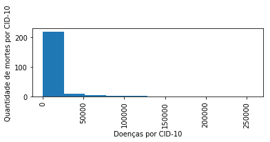

```
-=-=--=-=--=-=-=-=-=- Heatmaps da Mortalidade por Unidade da Federeal por Grupo CID-10 -=-=--=-=--=-=-=-=-=-
```

[figure not shown]

```python
plt.close('all')

print("-=-=--=-=--=-=-=-=-=- Gráfico da Mortalidade da Bahia por Groupo CID-10 -=-=--=-=--=-=-=-=-=-")
plt.figure(1)
plt.subplot(111)
plt.plot(dfMortalidadeCID10FaltantesMedia.index, dfMortalidadeCID10FaltantesMedia['BA'], "ro")
plt.xticks(rotation=90)
plt.title('Grupo CID-10')
plt.show()

print("-=-=--=-=--=-=-=-=-=- Histograma da Mortalidade da por Groupo CID-10 -=-=--=-=--=-=-=-=-=-")
plt.figure(2)
plt.subplot(211)
plt.xlabel("Doenças por CID-10")
plt.xticks(rotation=90)
plt.ylabel("Quantidade de mortes por CID-10")
plt.hist(dfMortalidadeCID10FaltantesMedia["BA"])

plt.show()

print("-=-=--=-=--=-=-=-=-=- Heatmaps da Mortalidade por Unidade da Federeal por Grupo CID-10 -=-=--=-=--=-=-=-=-=-")
sns.set()
plt.figure(3)
plt.subplot(311)
dfMortalidadeCID10FaltantesMedia.pivot_table(index="Grupo CID-10")
sns.heatmap(dfMortalidadeCID10FaltantesMedia, annot=True, fmt="g", cmap="viridis", robust=True, vmin=1, vmax=1000000,
            center=0, square=True)
plt.show()
```